# Human Activity Recognition - Weight Lifting Machine Learning

Maurício Collaça

December 5, 2017

## Summary

Six participants using sensors on the belt, forearm, arm and a dumbbell were asked to perform one set of 10 repetitions of the unilateral dumbbell biceps curl in five different fashions: exactly according to the specification (Class A), throwing the elbows to the front (Class B), lifting the dumbbell only halfway (Class C), lowering the dumbbell only halfway (Class D) and throwing the hips to the front (Class E). This experiment results a dataset.

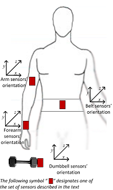

More information about this experiment [here](http://groupware.les.inf.puc-rio.br/har#weight_lifting_exercises).

The goal is to train a machine learning model using [training data](https://d396qusza40orc.cloudfront.net/predmachlearn/pml-training.csv) to predict the manner in which 20 [testing cases](https://d396qusza40orc.cloudfront.net/predmachlearn/pml-testing.csv) did the exercise.

The required model accuracy to correctly predict all 20 tests with 95% confidence is 0.9974. The estimated model accuracy is 0.9931. The estimated out-of-sample error is 0.0069.

## Data validation and transformation

Required libraries:

```r
library(dplyr); library(tidyr); library(ggplot2); library(GGally); library(caret)
```

Reading data with three types of missing values “NA”, “” and “#DIV/0!”.

```r
training <- read.csv("pml-training.csv", na.strings=c("NA","","#DIV/0!"))
testing <- read.csv("pml-testing.csv", na.strings=c("NA","","#DIV/0!"))
```

The training set has 19622 rows and 160 columns. The testing set has 20 rows and 160 columns. This is a multi-variate time-series dataset where each observation is identified by the variable `X`. Each observation belongs to a specific user name and exercise class, occurring one series of time windows, second and milliseconds. They hold variables containing raw data and summary statistics from the four sensors. The time-series observations are grouped by `classe`:

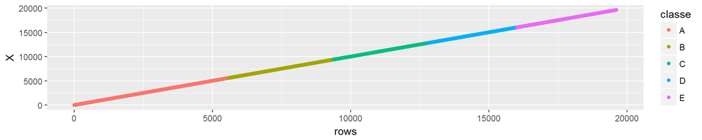

```r
ggplot(training, aes(x=1:nrow(training), y=X, color=classe)) + geom_point() + xlab("rows")
```

This contingency table shows training data reasonably distributed across users and classe:

```r
with(training, rbind(cbind(table(user_name, classe), "(total)" = table(user_name)),
                     "(total)" = c(table(classe), length(classe)))) %>% knitr::kable()
```

|  | A | B | C | D | E | (total) |
| --- | --- | --- | --- | --- | --- | --- |
| adelmo | 1165 | 776 | 750 | 515 | 686 | 3892 |
| carlitos | 834 | 690 | 493 | 486 | 609 | 3112 |
| charles | 899 | 745 | 539 | 642 | 711 | 3536 |
| eurico | 865 | 592 | 489 | 582 | 542 | 3070 |
| jeremy | 1177 | 489 | 652 | 522 | 562 | 3402 |
| pedro | 640 | 505 | 499 | 469 | 497 | 2610 |
| (total) | 5580 | 3797 | 3422 | 3216 | 3607 | 19622 |

100 training variables have high incidence of missing values.

```r
NA.proportion <- function(x) mean(is.na(x))
table(NA.proportion=round(sapply(training, NA.proportion),2))
```

```
NA.proportion
   0 0.98    1
  60   94    6
```

100 testing variables have 100% missing values.

```r
table(NA.proportion=sapply(testing, NA.proportion))
```

```
NA.proportion
  0   1
 60 100
```

Those missing values are due to statistics calculated in time windows recorded at rows whose column `new_window` = “yes”, characterizing a messy data set where rows are not always representing a single observation.

As the prediction model is being developed for the specific 20 testing cases, it should only hold predictors with actual data on both training and testing sets, therefore, variables with missing data will be dropped.

```r
missedTrainVars <- names(which(sapply(training, function(x) any(is.na(x)))))
missedTestVars <- names(which(sapply(testing, function(x) any(is.na(x)))))
missedVars <- unique(c(missedTrainVars, missedTestVars))
training <- select(training, -one_of(missedVars))
```

Training observations of a given user and classe are grouped in time windows of 1 second, therefore the average readings per window or per second are the same:

```r
group_by(training, user_name, classe) %>%
    summarise(readings_per_second=n()/n_distinct(num_window)) %>%
    select(user_name, classe, readings_per_second) %>% spread(classe, readings_per_second) %>%
    knitr::kable(col.names = gsub("_"," ",names(.)))
```

| user name | A | B | C | D | E |
| --- | --- | --- | --- | --- | --- |
| adelmo | 21.98113 | 22.17143 | 22.05882 | 21.45833 | 22.12903 |
| carlitos | 24.52941 | 22.25806 | 24.65000 | 24.30000 | 24.36000 |
| charles | 21.92683 | 22.57576 | 22.45833 | 21.40000 | 23.70000 |
| eurico | 23.37838 | 24.66667 | 22.22727 | 24.25000 | 23.56522 |
| jeremy | 24.52083 | 22.22727 | 23.28571 | 22.69565 | 22.48000 |
| pedro | 22.06897 | 21.95652 | 21.69565 | 23.45000 | 22.59091 |

Testing data contains only one observation per time window.

```r
with(testing, rbind(table(num_window, user_name), "(total)" = table(user_name)))
```

```
        adelmo carlitos charles eurico jeremy pedro
48           0        0       0      0      0     1
72           0        0       0      0      0     1
74           0        0       0      0      0     1
194          1        0       0      0      0     0
235          0        0       0      1      0     0
255          0        0       0      1      0     0
257          0        0       0      1      0     0
302          0        0       0      1      0     0
323          0        1       0      0      0     0
361          0        1       0      0      0     0
408          0        0       0      0      1     0
431          0        0       0      0      1     0
439          0        0       0      0      1     0
440          0        0       0      0      1     0
461          0        0       0      0      1     0
485          0        0       0      0      1     0
504          0        0       0      0      1     0
664          0        0       1      0      0     0
779          0        0       0      0      1     0
859          0        1       0      0      0     0
(total)      1        3       1      4      8     3
```

Therefore, it’s assumed the machine learning model wouldn’t predict on time-related variables and so they are dropped.

```r
select(training, matches("window|timestamp")) %>% names()
```

```
## [1] "raw_timestamp_part_1" "raw_timestamp_part_2" "cvtd_timestamp"
## [4] "new_window"           "num_window"
```

```r
training <- select(training, -matches("window|timestamp"))
```

The row identification variable `X` has no purpose in the training model and so it is dropped.

```r
training$X <- NULL
```

As both training and testings set contain the variable `user_name`, it will be leveraged in the model for user-refined predictions.

The new training set has 19622 rows and 54 columns.

## Exploratory Data Analysis

The following plot matrix shows feature patterns across the 5 classes, faceting on the 4 sensor sets. It must be zoomed to 200% for proper viewing.

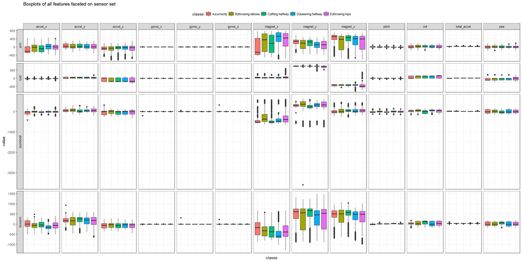

One can see the gyroscope-related features show the smallest range followed by the total acceleration and the pitch features. There are many outliers such as in magnetometer features with outstanding ones specifically in the magnet_dumbbell_feature.

It’s assumed that the Random Forest algorithm will not be much influenced by outliers so their treatment is out of the scope of this project.

## Model development

The estimated model accuracy to correctly predict all 20 tests with 95% confidence is $0.95 ^ \left(\frac{1}{20}\right)$ which is 0.9974386. Consequently, the expected error rate is 0.0025614.

```r
set.seed(1)
inTraining <- createDataPartition(training$classe, p = .60, list = FALSE)
training <- training[ inTraining,]
probing  <- training[-inTraining,]
```

The prediction algorithm to be used is the Breiman’s random forest from the r package `randomForest` version 4.6.12. One advantage is the accuracy and disadvantages are on speed, interpretability and overfitting. Its tuning parameter `mtry` sets the number of variables randomly sampled as candidates at each tree split. As the outcome `classe` is a categorical value, that’s a classification task whose default is the maximum integer lower than the square root of the number of predictors. Its tuning parameter `ntree` sets the number of trees to grow during the execution whose default is 500.

The training speed is improved through parallel processing, allowing multiple executions of the random forest at same time according to the number of CPU cores.

```r
library(parallel); library(doParallel)
cluster <- makeCluster(detectCores())
registerDoParallel(cluster)
cluster
```

```
socket cluster with 4 nodes on host 'localhost'
```

For this dataset, the default tuning parameter `mtry` is:

```r
floor(sqrt(ncol(training) - 1))
```

```
## [1] 7
```

However, the `randomForest` package makes available the function `tuneRF()` to tune for the optimal `mtry` parameter with respect to Out-of-Bag error estimate. This function is employed in a simulation to also estimate the optimal `ntree` parameter:

```r
tuneRFGrid <- expand.grid(stepFactor = 1.5, improve = 0.001, ntreeTry = c(50, 250, 500, 750, 1000))
clusterExport(cluster, "training")
ptm <- proc.time()
tunes <- parApply(cluster, tuneRFGrid, 1, function(param) {
    set.seed(1)
    ptm <- proc.time()
    tune <- randomForest::tuneRF(x=training[,-ncol(training)], y=training$classe, trace=FALSE, plot = FALSE,
                   stepFactor=param["stepFactor"], improve=param["improve"], ntreeTry=param["ntreeTry"])
    c(tune[which.min(tune[,2]),], (proc.time()-ptm)[3])
})
proc.time() - ptm
```

```
##    user  system elapsed
##    0.01    0.00  606.36
```

```r
tunes <- bind_cols(tuneRFGrid, as.data.frame(t(tunes)))
knitr::kable(tunes)
```

| stepFactor | improve | ntreeTry | mtry | OOBError | elapsed |
| --- | --- | --- | --- | --- | --- |
| 1.5 | 0.001 | 50 | 10 | 0.0083220 | 36.60 |
| 1.5 | 0.001 | 250 | 10 | 0.0066236 | 154.90 |
| 1.5 | 0.001 | 500 | 10 | 0.0061141 | 270.42 |
| 1.5 | 0.001 | 750 | 10 | 0.0055197 | 335.91 |
| 1.5 | 0.001 | 1000 | 10 | 0.0058594 | 598.42 |

The optimal `mtry` and `ntree` parameters have the minimum out-of-bag error.

```r
(mtry <- tunes$mtry[which.min(tunes$OOBError)])
```

```
[1] 10
```

```r
(ntree <- tunes$ntreeTry[which.min(tunes$OOBError)])
```

```
[1] 750
```

Cross-validation is also used to train different models with different resamples and tuning parameters in order to minimize the prediction bias, calculate a resampling based average accuracy and find the optimal model. Through the meta-package `caret` version 6.0.78, a k-fold cross-validation is performed with default 10 fold resampling to fit random forest models with different a grid of tuning parameters set from the range of the default and the optimal `mtry` parameter, considering the optimal `ntree` parameter.

The tune grid:

```r
tuneRange <- range(floor(sqrt(ncol(training) - 1)), tunes$mtry[which.min(tunes$OOBError)])
tuneGrid <- data.frame(mtry = min(tuneRange):max(tuneRange))
tuneGrid$mtry
```

```
[1]  7  8  9 10
```

The 10 k-fold cross-validated random forest model training using the tune grid:

```r
set.seed(1)
ptm <- proc.time()
fit <- train(classe ~ ., training, method = "rf", tuneGrid = tuneGrid, ntree=ntree,
             trControl = trainControl(method = "cv", number = 10, search = "grid"))
proc.time() - ptm
```

```
   user  system elapsed
  65.84    0.43 1417.85
```

Disable parallel processing

```r
stopCluster(cluster)
registerDoSEQ()
```

The training summary shows the accuracy of the best model resulted from 10 k-fold cross-validation and the final `mtry` parameter.

```r
fit
```

```
Random Forest

11776 samples
   53 predictor
    5 classes: 'A', 'B', 'C', 'D', 'E'

No pre-processing
Resampling: Cross-Validated (10 fold)
Summary of sample sizes: 10598, 10598, 10599, 10598, 10599, 10598, ...
Resampling results across tuning parameters:

  mtry  Accuracy   Kappa
   7    0.9921872  0.9901170
   8    0.9931217  0.9912994
   9    0.9924420  0.9904398
  10    0.9923574  0.9903329

Accuracy was used to select the optimal model using the largest value.
The final value used for the model was mtry = 8.
```

The confusion matrix estimated from the training resamples:

```r
confusionMatrix.train(fit)
```

```
Cross-Validated (10 fold) Confusion Matrix

(entries are percentual average cell counts across resamples)

          Reference
Prediction    A    B    C    D    E
         A 28.4  0.1  0.0  0.0  0.0
         B  0.0 19.2  0.1  0.0  0.0
         C  0.0  0.1 17.3  0.2  0.0
         D  0.0  0.0  0.0 16.2  0.1
         E  0.0  0.0  0.0  0.0 18.3

 Accuracy (average) : 0.9931
```

On the training data, the expected out of sample error is:

```r
(expectedError <- (1 - fit$results$Accuracy[which.max(fit$results$Accuracy)]))
```

```
## [1] 0.006878297
```

Predicting on the probing set.

```r
probePredict <- predict(fit, probing)
```

```r
confusionMatrix(probePredict, probing$classe)
```

```
Confusion Matrix and Statistics

          Reference
Prediction    A    B    C    D    E
         A 1363    0    0    0    0
         B    0  889    0    0    0
         C    0    0  821    0    0
         D    0    0    0  770    0
         E    0    0    0    0  858

Overall Statistics

               Accuracy : 1
                 95% CI : (0.9992, 1)
    No Information Rate : 0.2899
    P-Value [Acc > NIR] : < 2.2e-16

                  Kappa : 1
 Mcnemar's Test P-Value : NA

Statistics by Class:

                     Class: A Class: B Class: C Class: D Class: E
Sensitivity            1.0000   1.0000   1.0000   1.0000   1.0000
Specificity            1.0000   1.0000   1.0000   1.0000   1.0000
Pos Pred Value         1.0000   1.0000   1.0000   1.0000   1.0000
Neg Pred Value         1.0000   1.0000   1.0000   1.0000   1.0000
Prevalence             0.2899   0.1891   0.1746   0.1638   0.1825
Detection Rate         0.2899   0.1891   0.1746   0.1638   0.1825
Detection Prevalence   0.2899   0.1891   0.1746   0.1638   0.1825
Balanced Accuracy      1.0000   1.0000   1.0000   1.0000   1.0000
```

## Prediction of 20 test cases

The prediction model is used to predict 20 test cases required from the quiz.

```r
cbind(testing[, c("user_name","problem_id")],  prediction=predict(fit, testing)) %>% knitr::kable()
```

| user_name | problem_id | prediction |
| --- | --- | --- |
| pedro | 1 | B |
| jeremy | 2 | A |
| jeremy | 3 | B |
| adelmo | 4 | A |
| eurico | 5 | A |
| jeremy | 6 | E |
| jeremy | 7 | D |
| jeremy | 8 | B |
| carlitos | 9 | A |
| charles | 10 | A |
| carlitos | 11 | B |
| jeremy | 12 | C |
| eurico | 13 | B |
| jeremy | 14 | A |
| jeremy | 15 | E |
| eurico | 16 | E |
| pedro | 17 | A |
| carlitos | 18 | B |
| pedro | 19 | B |
| eurico | 20 | B |

## References

Velloso, E.; Bulling, A.; Gellersen, H.; Ugulino, W.; Fuks, H. Qualitative Activity Recognition of Weight Lifting Exercises. Proceedings of 4th International Conference in Cooperation with SIGCHI (Augmented Human ’13) . Stuttgart, Germany: ACM SIGCHI, 2013.